# Assignment 9 Report

Austen Miller

2023-03-23

```r
library(tidyverse)
library(modelr)
library(easystats)
library(GGally)
```

# Use the data set “/Data/GradSchool_Admissions.csv”

```r
df <- read.csv("./GradSchool_Admissions.csv")
```

# You will explore and model the predictors of graduate school admission

The “admit” column is coded as 1=success and 0=failure (that’s binary, so model appropriately)  
The other columns are the GRE score, the GPA, and the rank of the undergraduate institution, where I is “top-tier.”

Okay so let’s take a look:

```r
glimpse(df)
```

```
## Rows: 400
## Columns: 4
## $ admit <int> 0, 1, 1, 1, 0, 1, 1, 0, 1, 0, 0, 0, 1, 0, 1, 0, 0, 0, 0, 1, 0, 1…
## $ gre   <int> 380, 660, 800, 640, 520, 760, 560, 400, 540, 700, 800, 440, 760,…
## $ gpa   <dbl> 3.61, 3.67, 4.00, 3.19, 2.93, 3.00, 2.98, 3.08, 3.39, 3.92, 4.00…
## $ rank  <int> 3, 3, 1, 4, 4, 2, 1, 2, 3, 2, 4, 1, 1, 2, 1, 3, 4, 3, 2, 1, 3, 2…
```

That’s gonna need a little fixing.

```r
df$admit <- as.logical(df$admit)
df$rank <- as.factor(df$rank)
```

Now let’s see

```r
glimpse(df)
```

```
## Rows: 400
## Columns: 4
## $ admit <lgl> FALSE, TRUE, TRUE, TRUE, FALSE, TRUE, TRUE, FALSE, TRUE, FALSE, …
## $ gre   <int> 380, 660, 800, 640, 520, 760, 560, 400, 540, 700, 800, 440, 760,…
## $ gpa   <dbl> 3.61, 3.67, 4.00, 3.19, 2.93, 3.00, 2.98, 3.08, 3.39, 3.92, 4.00…
## $ rank  <fct> 3, 3, 1, 4, 4, 2, 1, 2, 3, 2, 4, 1, 1, 2, 1, 3, 4, 3, 2, 1, 3, 2…
```

That’s better.

Let’s start looking at it:

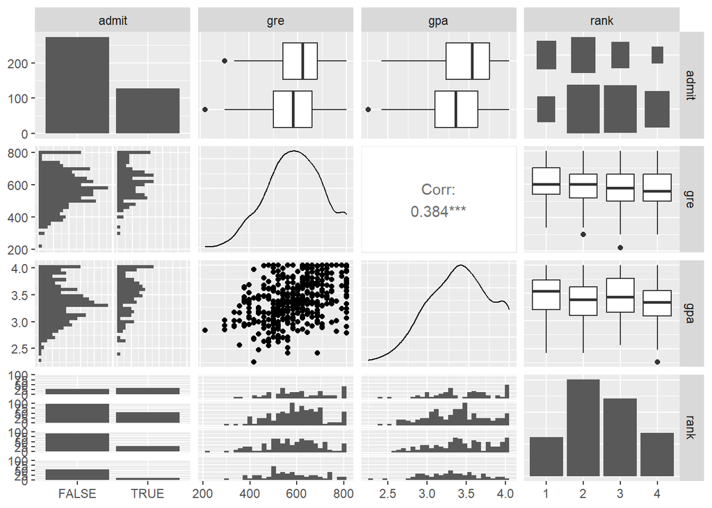

```r
df %>%
  select(admit,gre,gpa,rank) %>%
  ggpairs()
```

To me this looks like all three variables matter, but rank seems to matter more. It is interesting how rank doesn’t seem to predict GPA and GRE as well as you would think.

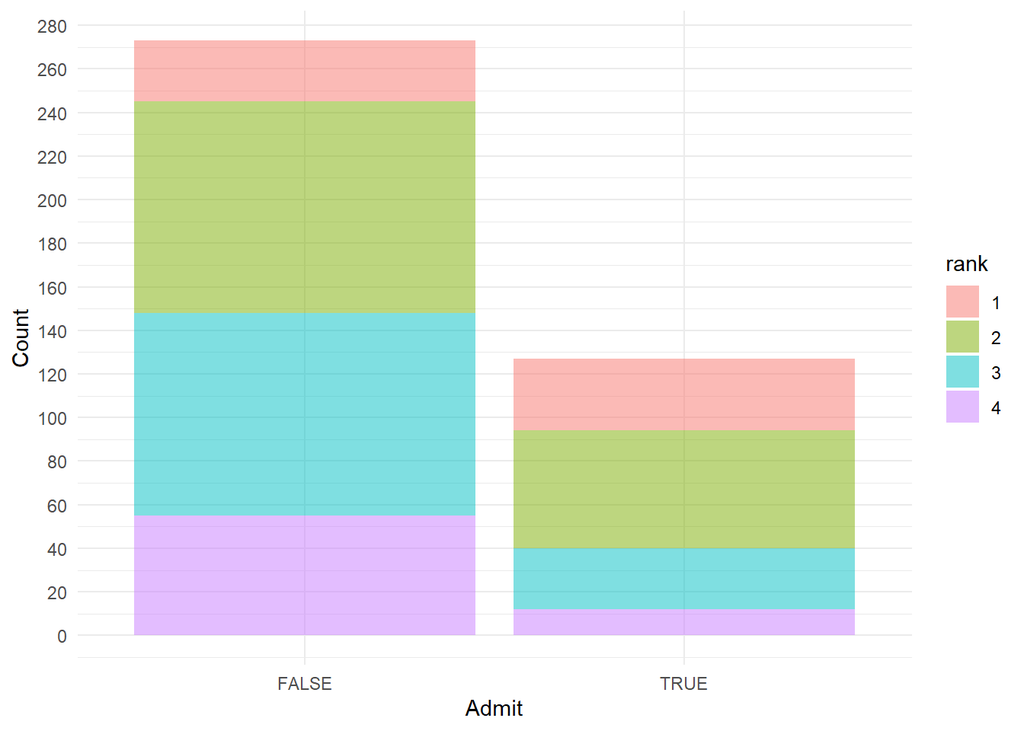

```r
df %>%
  ggplot(aes(x=admit,fill=rank)) +
  geom_bar(alpha=.5) +
  theme_minimal() +
  scale_y_continuous(n.breaks = 15) +
  labs(x = "Admit",
       y = "Count")
```

Yes yes, bar graphs bad. This shows the difference kind of well though. The ratio of Rank 1 schools is almost 1:1, but rank 4 is around 5:1.

Let’s make some mods.

```r
mod1 <- glm(data = df,
            formula = admit ~ gpa + gre)

mod2 <- glm(data = df,
            formula = admit ~ gpa * gre)

mod3 <- glm(data = df,
           formula = admit ~ gre + gpa + rank,
           family = "binomial")

mod4 <- glm(data = df,
            formula = admit ~ (gre * gpa) + rank,
            family = "binomial")
```

Earlier it seemed like GPA and GRE scores were both important, but also were about the same. A mostly linear relationship that doesn’t appear to be quite as predictive as rank. So, we’ve got boring mod1 and mod2 here mostly to see how much more rank matters

How *do* they do against each other?

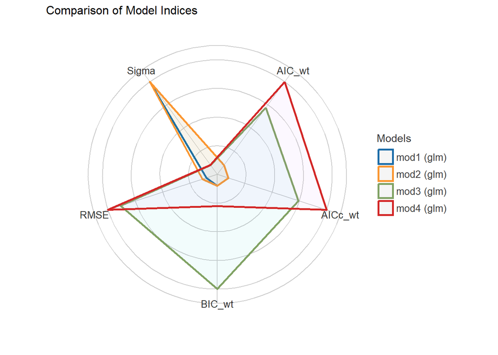

```r
compare_performance(mod1,mod2,mod3,mod4) %>%
  plot()
```

mod3 looks like the best to me. From my (admittedly kind of vague) understanding, AIC and BIC penalize over-fitting. I’m inclined to go with the model that does the best across those scores.

Some plots with predictions:

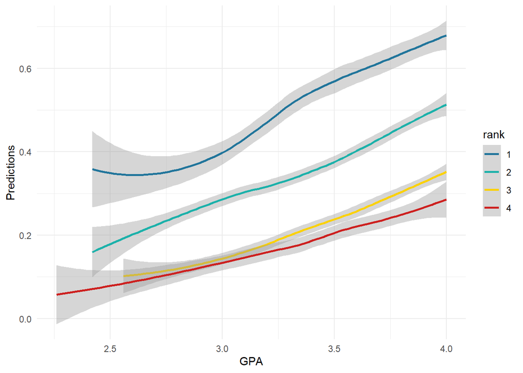

```r
preds <- add_predictions(df,mod3,type = "response")

preds %>%
  ggplot(aes(x = gpa, y = pred, color = rank, group = rank))+
  geom_smooth() +
  theme_minimal() +
  labs(x = "GPA",
       y = "Predictions") +
  scale_colour_social()
```

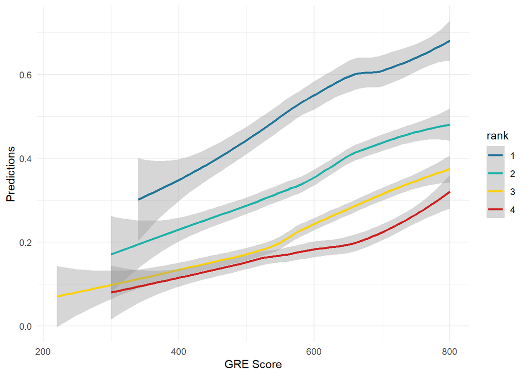

```r
preds %>%
  ggplot(aes(x=gre,y=pred,color=rank,group=rank)) +
  geom_smooth() +
  theme_minimal() +
  labs(x = "GRE Score",
       y = "Predictions") +
  scale_colour_social()
```

I wanted to find a better way to do this, but could not. Maybe something like a pivot_wider on gpa/gre, making that a factor, and then facet_wrapping on that, but I’m pretty sure that would mess up the data. It would put the GRE and GPA values in the same column.

Ngl, this data is a little depressing. I take it that these are real stats? Oof.